# Shiny Application Presentation

Nicholas Ong

11/28/2020

# Executive Summary

This is an assignment by John Hopkins University’s Coursera Course - Developing Data Products - Week 4 Project. Below is the requirement:

- Write a shiny application with associated supporting documentation. The documentation should be thought of as whatever a user will need to get started using your application.
- Deploy the application on Rstudio’s shiny server
- Share the application link by pasting it into the provided text box
- Share your server.R and ui.R code on github

# Data - mtcars

The dataset is from standard R package - mtcars. For previewing the data, below is the code:

```r
head(mtcars)
```

```
##                    mpg cyl disp  hp drat    wt  qsec vs am gear carb
## Mazda RX4         21.0   6  160 110 3.90 2.620 16.46  0  1    4    4
## Mazda RX4 Wag     21.0   6  160 110 3.90 2.875 17.02  0  1    4    4
## Datsun 710        22.8   4  108  93 3.85 2.320 18.61  1  1    4    1
## Hornet 4 Drive    21.4   6  258 110 3.08 3.215 19.44  1  0    3    1
## Hornet Sportabout 18.7   8  360 175 3.15 3.440 17.02  0  0    3    2
## Valiant           18.1   6  225 105 2.76 3.460 20.22  1  0    3    1
```

- You could access the shiny webapp by clicking [here](https://huaigim.shinyapps.io/ShinyApplicationProject/).
- If you want to find out more information of the server.R and ui.R code, you could also visit my github repository [here](https://github.com/huaigim/JHU_DevelopingDataProducts_ShinyApplicationProject).

# Machine Learning Algorithm

Linear model is used to run the machine learning algorithm, to predict mileage per gallon based on variables selected by end-user. - Below is an illustration using ‘No. of cylinders’ variable - The output/ result will be stored in a variable called fit

```r
fit <- lm(mpg ~ cyl, mtcars)
```

# Result

After running the model, the fit result and plot will be shown to the end-user

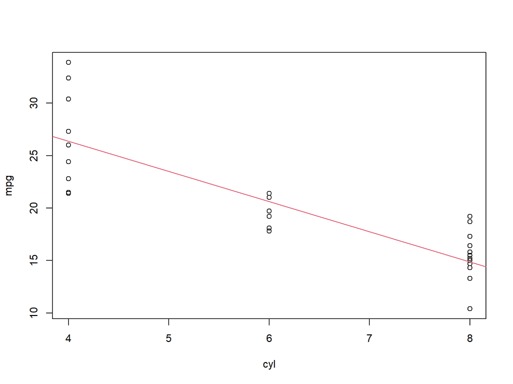

```r
with(mtcars, {plot(mpg ~ cyl)
        abline(fit, col = 2)})
```

```r
fit
```

```
##
## Call:
## lm(formula = mpg ~ cyl, data = mtcars)
##
## Coefficients:
## (Intercept)          cyl
##      37.885       -2.876
```